# space{3.5in}Analysis of Accidental Drug Related Deaths

## Missing Data Exploration

We began by exploring the missing values in the dataset. This is crucial as it guides us towards assessing the usability of the data i.e if a column has too many missing values it might be better to not use it. It further guided us on building the interaction variables i.e we assure that the columns involved in the analysis have sufficient values.

The data thus seems to be usable for our analysis.

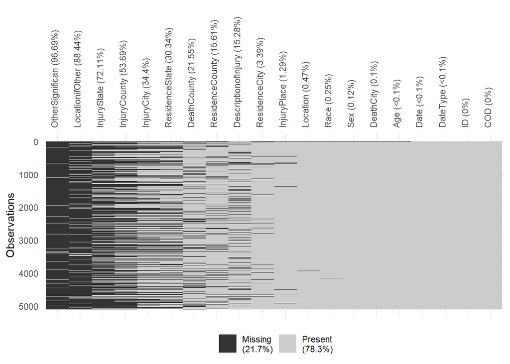

```r
#Replacing blank values with NA
drug_acc <- df_main
#1st 20 parameters
vis_miss(drug_acc [,c(1:20)], sort_miss = TRUE) +
 theme(axis.text.x = element_text(angle = 90))
```

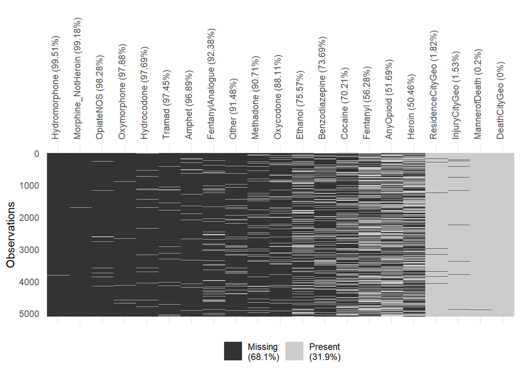

```r
#2nd 21 parameters
vis_miss(drug_acc [,c(21:41)], sort_miss = TRUE) +
 theme(axis.text.x = element_text(angle = 90))
```

# Demographical Aspect of Drug Abuse

## Assessing the distribution of fields

Once we have identified the parameters containing sufficient data, we now assess the distribtion of each of these variables i.e we visualize the spread of numeric data, the frequency of the categories with a column, the proportion of death along various axis etc. This paves the way in identifying the parameters which need to be further explored for truly unravelling drug abuse situation here.

1. **Location of Injury and Location of Death**

The data consists of information pertaining to both Location of Injury and Location of Death. We wanted to understand if the location of injury is same as that of death, which could have potentially suggested that post drug abuse death might be instantaneous as people did not have time to relocate. Here, we observe that majority of death occurs in residence followed by hospitals. However, majority of injuries also occur at Residence potentially suggesting that most injuries and deaths occur at Residence. This probes us to further investigate:

- Which cities/states have more residences reporting death due to drugs?

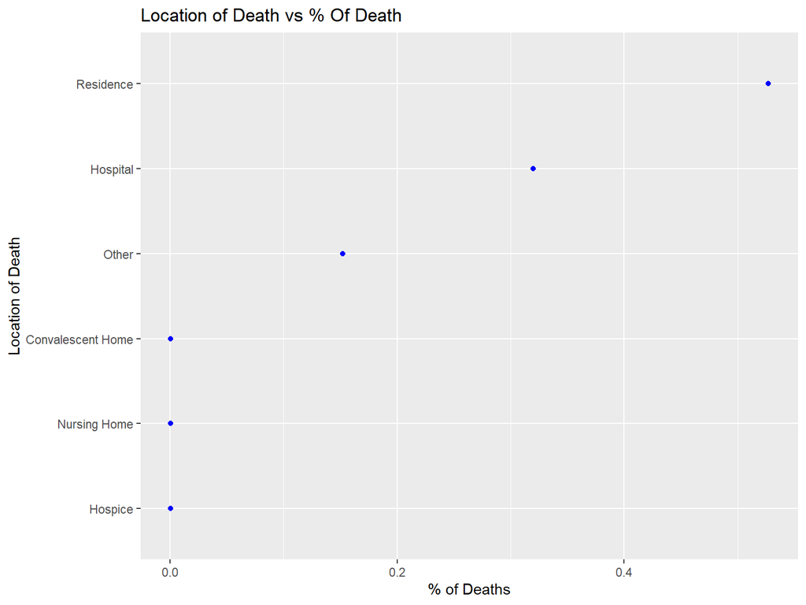

```r
# By visualizing the location of death
x<- df_main %>%
    select(Location) %>%
    na.omit()

death_by_loc <- x %>%
                group_by(Location=x$Location) %>%
                summarise(Freq=n()) %>%
                mutate(perc_Death=Freq/nrow(x))
#Graph plot
ggplot(death_by_loc,aes(x = perc_Death, y = reorder(Location, perc_Death))) +
    geom_point(color = "blue")+
  ggtitle("Location of Death vs % Of Death")+
  xlab('% of Deaths') +
  ylab ('Location of Death')
```

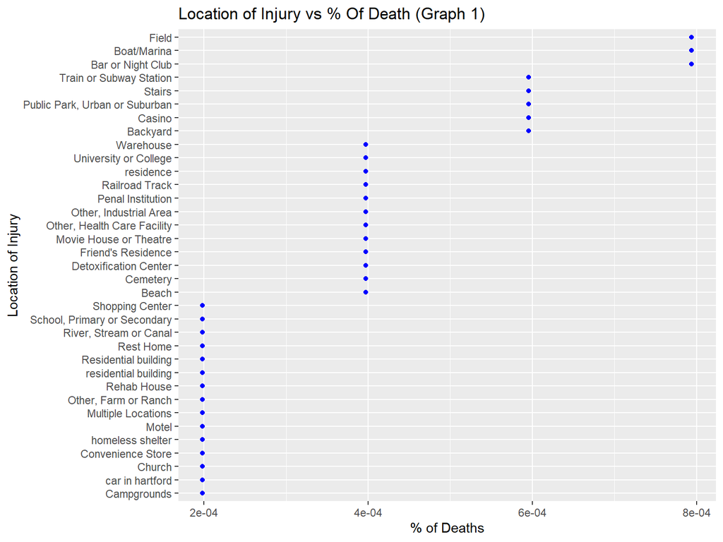

```r
# Visualizing the location of injury
x<- df_main %>%
    select(InjuryPlace) %>%
    na.omit()
injury_by_loc <- x %>%
                group_by(InjuryPlace=x$InjuryPlace) %>%
                summarise(Freq=n()) %>%
                mutate(perc_Injury=Freq/nrow(x))
injury_by_loc <- injury_by_loc[order(injury_by_loc$perc_Injury),]

#Graph plot
ggplot(injury_by_loc[c(1:35),],aes(x = perc_Injury, y = reorder(InjuryPlace, perc_Injury))) +
    geom_point(color = "blue")+
  ggtitle("Location of Injury vs % Of Death (Graph 1)")+
   xlab('% of Deaths') +
  ylab ('Location of Injury')
```

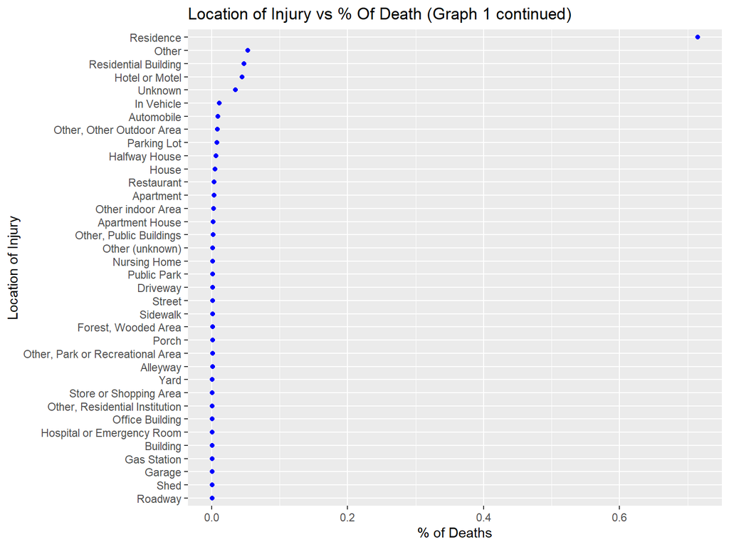

```r
ggplot(injury_by_loc[c(36:71),],aes(x = perc_Injury, y = reorder(InjuryPlace, perc_Injury))) +
    geom_point(color = "blue")+
  ggtitle("Location of Injury vs % Of Death (Graph 1 continued) ")+
   xlab('% of Deaths') +
  ylab ('Location of Injury')
```

2. **Age** : Since age is the only continuous variable available here, we proceed by analyzing its distribution across other categorial variables.The overall data appears to be bimodal at the ages ~28-30 and ~50 years. The plot appears to be skewed to the right

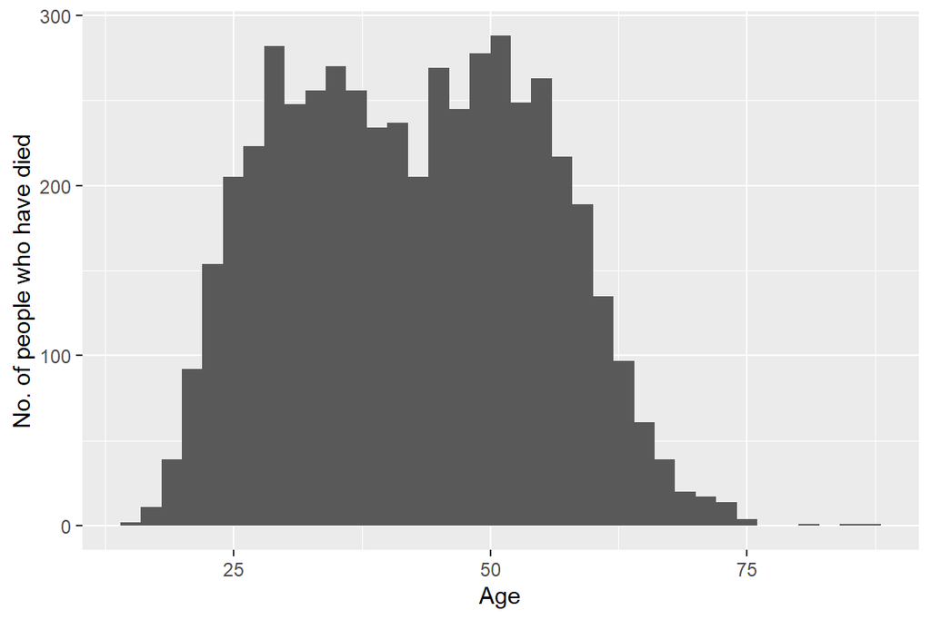

```r
#Age
ggplot(drug_acc, aes(x=Age)) +
  geom_histogram(binwidth = 2, boundary = 0, closed = "left") +
  ylab('No. of people who have died')
```

```r
  ggtitle("Historgam of the Age Group")
```

```
## $title
## [1] "Historgam of the Age Group"
##
## attr(,"class")
## [1] "labels"
```

3. **Sex**
- The number of males who die due to drug overdose is more than twice that of females.
- The median age of females who die due to drug abuse is more than males

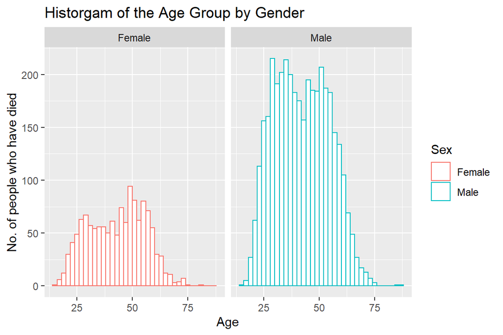

```r
#Sex
ggplot(filter(drug_acc, Sex == "Female" | Sex=='Male'), aes(x=Age,color=Sex)) +
  geom_histogram(binwidth = 2, boundary = 0, closed = "left",fill='white') +
  ggtitle("Historgam of the Age Group by Gender") +
  ylab('No. of people who have died')+
  facet_wrap(~Sex)
```

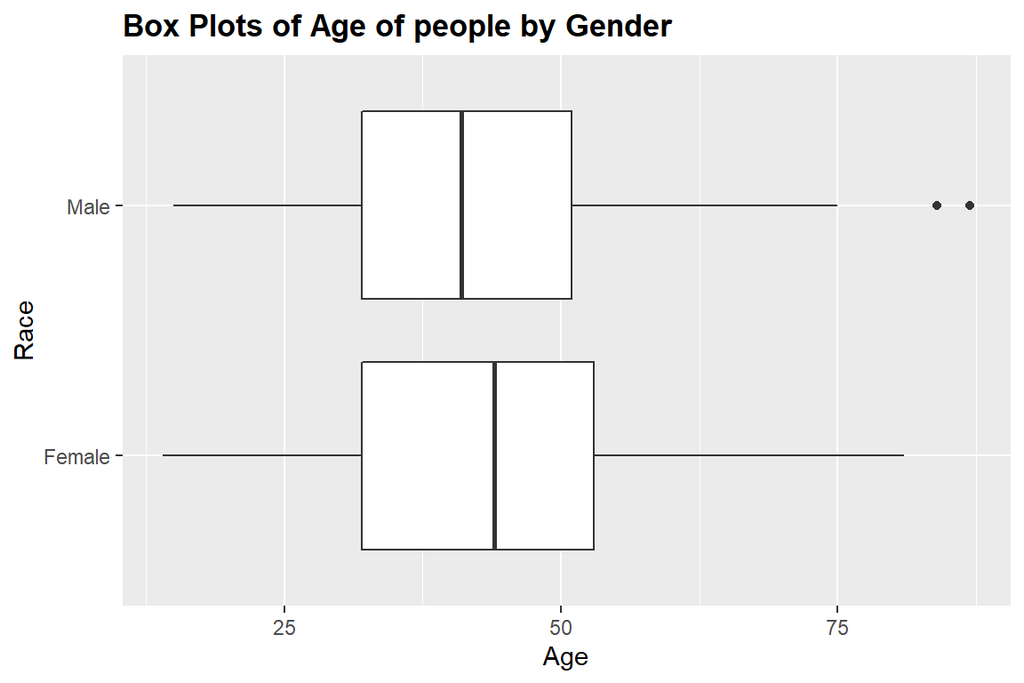

```r
#Sex and Age
ggplot(data=filter(drug_acc, Sex == "Female" |  Sex=='Male'),aes(x=reorder(Sex,-Age,FUN=median), y=Age)) +
  geom_boxplot() +
  ggtitle("Box Plots of Age of people by Gender") +
  xlab("Race") +
  ylab("Age") +
  theme(plot.title = element_text(face = "bold"))+
  coord_flip()
```

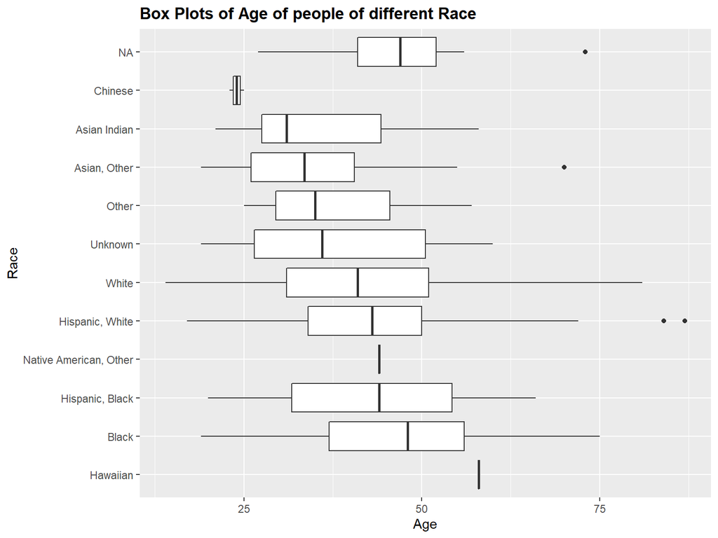

```r
#Race and Age
ggplot(data=drug_acc,aes(x=reorder(Race,-Age,FUN=median), y=Age)) +
  geom_boxplot() +
  ggtitle("Box Plots of Age of people of different Race") +
  xlab("Race") +
  ylab("Age") +
  theme(plot.title = element_text(face = "bold"))+
  coord_flip()
```

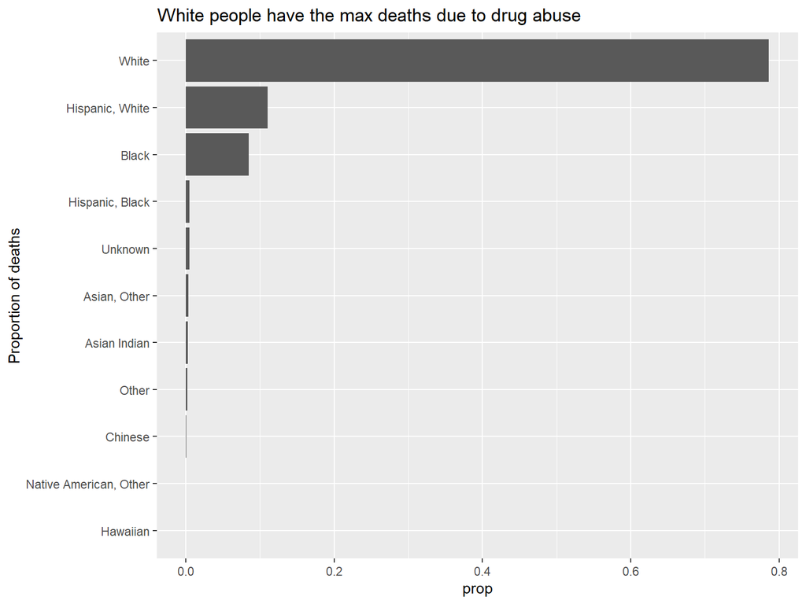

```r
race_plot<-drug_acc %>%
  filter(!is.na(Race))%>%
  group_by(Race)%>%
  summarize(Freq=n()) %>%
  mutate(prop=Freq/sum(Freq)) %>%
  ggplot()+
  geom_bar(aes(x=reorder(Race,prop), y=prop),stat='identity')+
  coord_flip()+
  ggtitle('White people have the max deaths due to drug abuse')+
  xlab('Proportion of deaths')

race_plot
```

## Spatial Analysis

1. **Sex** Gender based drug abuse has always been a topic of discussion when it comes to analysis regarding drugs. To find the corresponding insights for our dataset and county based distribution of the same lead us to plot choropleth plots for our analysis.

The choropleth plot below represents the number of accidental deaths due to drug abuse in the state of Connecticut according to its various counties.

- The number of males who died due to drug abuse are on the whole more than the number of females who died due to drug abuse for the years 2012 to 2018 which can be inferred from the fact that the choropleth plot for males has darker shades of purple than the choropleth plot for females.
- As it can be inferred from the plot, the county of Hartford has more number of deaths due to drug abuse as compared to other counties for males as well as females.
- The number of deaths in the counties of Middlesex and Tolland are very less as compared to other counties for males as well as females.

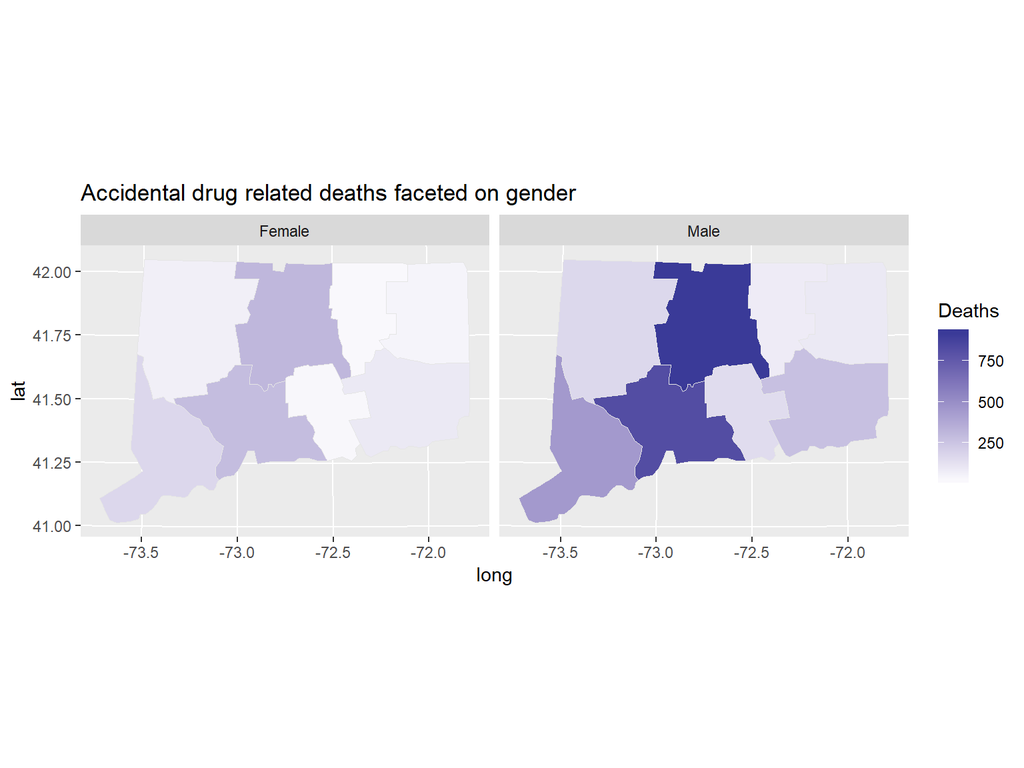

```r
#Reading the dataset
#Replacing blank values with NA
demo_df <- drug_acc

#adding a new column age group
demo_df$age_grp<-demo_df$Age
demo_df$age_grp <- ifelse((demo_df$Age>=14 & demo_df$Age<=19) , 'teens',demo_df$age_grp)
demo_df$age_grp <- ifelse((demo_df$Age>=20 & demo_df$Age<=40) , 'young',demo_df$age_grp)
demo_df$age_grp <- ifelse((demo_df$Age>=41 & demo_df$Age<=60) , 'mid',demo_df$age_grp)
demo_df$age_grp <- ifelse((demo_df$Age>=61) , 'old',demo_df$age_grp)

demo_df$statename <- abbr2state(demo_df$ResidenceState)
demo_df$DeathCity <- tolower(demo_df$DeathCity)
demo_df <- demo_df %>% filter(!is.na(demo_df$DeathCounty ))
#unique(demo_df$DeathCity)
k <- demo_df %>%
  count(demo_df$DeathCounty,demo_df$Sex)

names(k)[names(k) == "demo_df$DeathCounty"] <- "subregion"
names(k)[names(k) == "demo_df$Sex"] <- "gender"
k <- k %>% filter(gender != "Unknown")
k <- k %>% filter(!is.na(subregion ))
us_county <- map_data("county")
us_county <- us_county[us_county$region == "connecticut", ]
k$subregion <- tolower(k$subregion)
deathdf <- left_join(us_county, k)
#deathdf
q <- ggplot(data = deathdf,
            aes(x = long, y = lat,
                group = group, fill = deathdf$n))

q + geom_polygon(color = "gray90", size = 0.1) +
  coord_map(projection = "albers", lat0 = 39, lat1 = 45) +
  labs(title = "Accidental drug related deaths faceted on gender", fill="Deaths") +
  scale_fill_gradient2()+
  facet_wrap(vars(deathdf$gender))
```

2. **Age**

Research regarding the age groups involved in drugs and their effects has been of interest since decades.Getting county wise insights regarding the age group of people who died due to drug abuse being our primary aim lead to us plotting choropleth plot faceted on age.

We wanted to explore the distribution of the number of deaths due to drug abuse across the various age groups over the different counties of the state of Connecticut. The below choropleth plot represents the number of deaths due to drug abuse for the different age groups with teens being people with age less than 19, young being people with age less than 40, mid being people with age less than 60 and old being people with age greater than 60.

- There are very few teens who have died due to drug abuse in the state of connecticut.
- There are very few old people who have died of drug abuse in the state.
- Maximum number of people who died due to drug abuse were people between the age group of 20 to 60.
- Similarly as above, Hartford county has the maximum number of deaths due to drugs for mid and young aged people from the year 2012 to 2018.

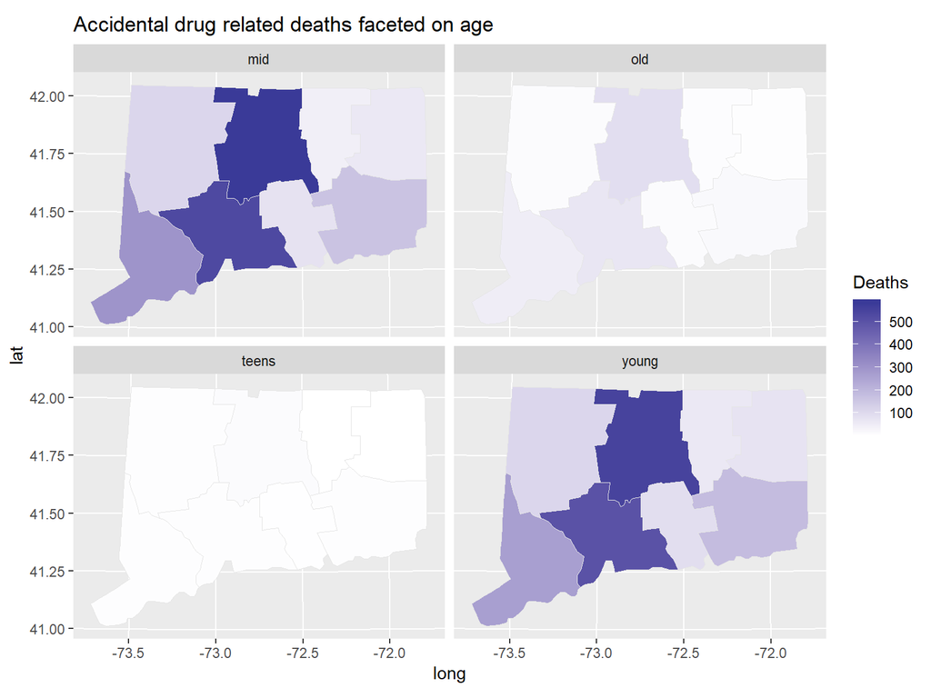

```r
k_age <- demo_df %>%
  count(demo_df$DeathCounty,demo_df$age_grp)
#%>%
names(k_age)[names(k_age) == "demo_df$DeathCounty"] <- "subregion"
names(k_age)[names(k_age) == "demo_df$age_grp"] <- "age"

#k <- k %>% filter(gender != "Unknown")
k_age <- k_age %>% filter(!is.na(subregion ))

us_county <- map_data("county")
us_county <- us_county[us_county$region == "connecticut", ]
k_age$subregion <- tolower(k_age$subregion)
deathdf_age <- left_join(us_county, k_age)
#deathdf_age
q <- ggplot(data = deathdf_age,
            aes(x = long, y = lat,
                group = group, fill = deathdf_age$n))

q + geom_polygon(color = "gray90", size = 0.1) +
  coord_map(projection = "albers", lat0 = 39, lat1 = 45) +
  labs(title = "Accidental drug related deaths faceted on age", fill="Deaths") +
  scale_fill_gradient2()+
  facet_wrap(vars(deathdf_age$age))
```

3. **Race**

We wanted to identify the distribution of the race of the people who died due to drug abuse. We have plotted a choropleth plot for the death count for different ethnicity valuess.

- The ethnicity of the people who died due to drug abuse was mostly “white”.
- There weren’t any Chinese people who died due to drug abuse in the counties except in county of New Haven.
- The counties of Hartford, New Haven, Middlesex and Fairfield had hardly any Asian Indian people who died due to drug abuse.
- The counties of Hartford, New Haven and Fairfield had quite a few people of the black and hispanic white race who died due to drug abuse.

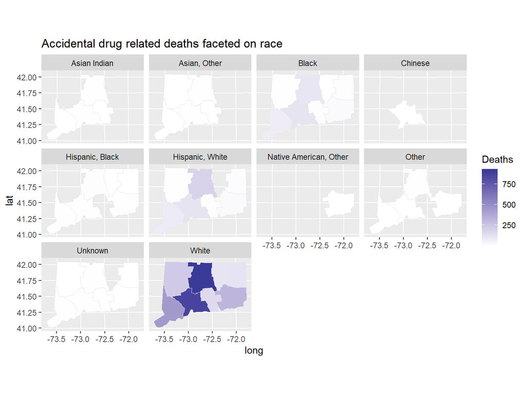

```r
k_race <- demo_df %>%
  count(demo_df$DeathCounty,demo_df$Race)
#%>%
names(k_race)[names(k_race) == "demo_df$DeathCounty"] <- "subregion"
names(k_race)[names(k_race) == "demo_df$Race"] <- "race"
k_race <- k_race %>% filter(!is.na(race))
k_race <- k_race %>% filter(!is.na(subregion ))
us_county <- map_data("county")
us_county <- us_county[us_county$region == "connecticut", ]
k_race$subregion <- tolower(k_race$subregion)

deathdf_race <- left_join(us_county, k_race)

q <- ggplot(data = deathdf_race,
            aes(x = long, y = lat,
                group = group, fill = deathdf_race$n))

q + geom_polygon(color = "gray90", size = 0.1) +
  coord_map(projection = "albers", lat0 = 39, lat1 = 45) +
  labs(title = "Accidental drug related deaths faceted on race", fill="Deaths") +
  scale_fill_gradient2()+
  facet_wrap(vars(deathdf_race$race))
```

4. **Years 2012-2018**